# Data Science Fundamentals I: Unemployment in Indonesia Demo

Matthew Jeremy and Wilson Chandra

July 11, 2017

# 1 Background

## 1.1 Objective

Our goal is to perform exploratory data analysis and visualize unemployment rates across all provinces in Indonesia with respect to particular variables. This project aims to gain a better understanding of how these variables relate to the unemployment rate through various methods and techniques of data visualization.

## 1.2 Sources

For this particular project, we relied on the following two sources:

1. [data.go.id](https://goo.gl/Sj33FF)
2. [Badan Pusat Statistik (BPS)](https://goo.gl/9W8qTq)

## 1.3 Variables to Analyze

In our exploratory data analysis, we utilized and analyzed several variables in order to create the visualizations that we will come across in this presentation. These variables include:

- Amount of illiterates and non-Bahasa speakers per province ([LINK](https://goo.gl/ePifWi))
- Demographics for various education levels per province ([LINK](https://goo.gl/MfKJcn))
- Populations of provinces across Indonesia ([LINK](https://goo.gl/ZVqdPS))
- Labor participation rate per province ([LINK](https://goo.gl/5t9btL))
- Unemployment rate per province ([LINK](https://goo.gl/swYmHd))

# 2 Setup

Before proceeding with importing our first dataset, let us begin by clearing up the global environment.

```r
# Initial configurations to clear the workspace and set to print numeric values
options(scipen = 9999)
rm(list=ls())
```

Also, this next code chunk will load all of the packages we used for our project. If these are not present in your library, please install them immediately.

```r
# install packages command: > install.packages("package_name")
library(ggplot2)
library(dplyr)
library(gridExtra)
library(reshape)
library(maps)
```

# 3 Literacy Rate

```r
# Proceed by importing Literacy Rate data into 'literacy' data frame
literacy <- read.csv("literacy_data.csv")
str(literacy)
```

```
## 'data.frame':    497 obs. of  8 variables:
##  $ kode_provinsi            : int  11 11 11 11 11 11 11 11 11 11 ...
##  $ nama_provinsi            : Factor w/ 33 levels "Aceh","Bali",..: 1 1 1 1 1 1 1 1 1 1 ...
##  $ kode_kabkota             : int  1101 1102 1103 1104 1105 1106 1107 1108 1109 1110 ...
##  $ nama_kabkota             : Factor w/ 497 levels "Kab. Aceh Barat",..: 336 6 5 9 10 8 1 3 290 57 ...
##  $ tidak_baca_tulis         : int  5195 12296 21776 13852 24431 10249 16444 20757 27071 22201 ...
##  $ tidak_berbahasa_indonesia: int  1638 5354 19819 4571 25837 2065 13142 22126 53228 38231 ...
##  $ latitude                 : num  2.63 2.44 3.26 3.6 4.57 ...
##  $ longitude                : num  96.1 97.9 97.2 97.7 97.8 ...
```

From this ‘literacy’ dataset, we will be focusing on the population of people who cannot read (tidak_baca_tulis) or speak in Bahasa Indonesia (tidak_berbahasa_indonesia) based on different provinces (nama_provinsi) across the country during the year of 2010.

The current state of this data frame organizes the number of people based on “kabupaten,” also known as subprovince, in which there are multiple of these in a single province. Since there is an inconsistent amount of subprovinces per province, we decided to clean this dataset by summing all the people within the same province to make a new data frame that looks like the following:

```r
rbind(head(literacy_clean, 2), tail(literacy_clean,2))
```

```
##            province cant_read cant_speak_bahasa
## 1              Aceh    328067            320048
## 2              Bali    425806            332539
## 32 Sumatera Selatan    417097            509532
## 33   Sumatera Utara    717804            439685
```

The number of people unable to read and unable to speak Bahasa Indonesia based on province is visualized below:

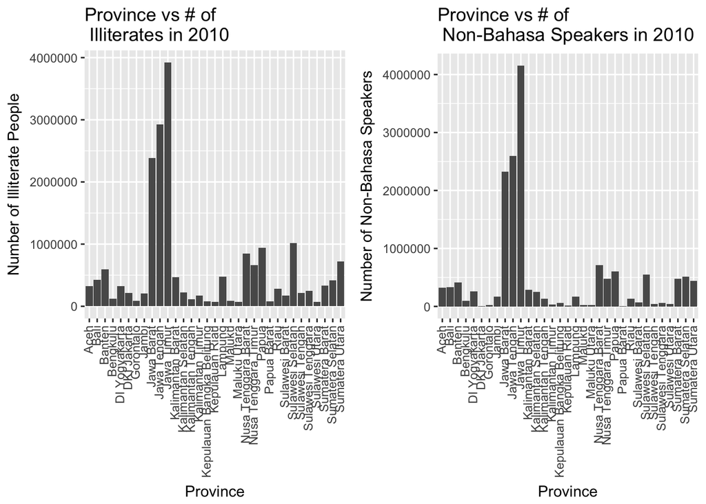

```r
grid.arrange(plot_lit1, plot_lit2, ncol=2)
```

To provide a different view, this next method attempts to find the percentage of the population for each province who are illiterate and unable to speak Bahasa:

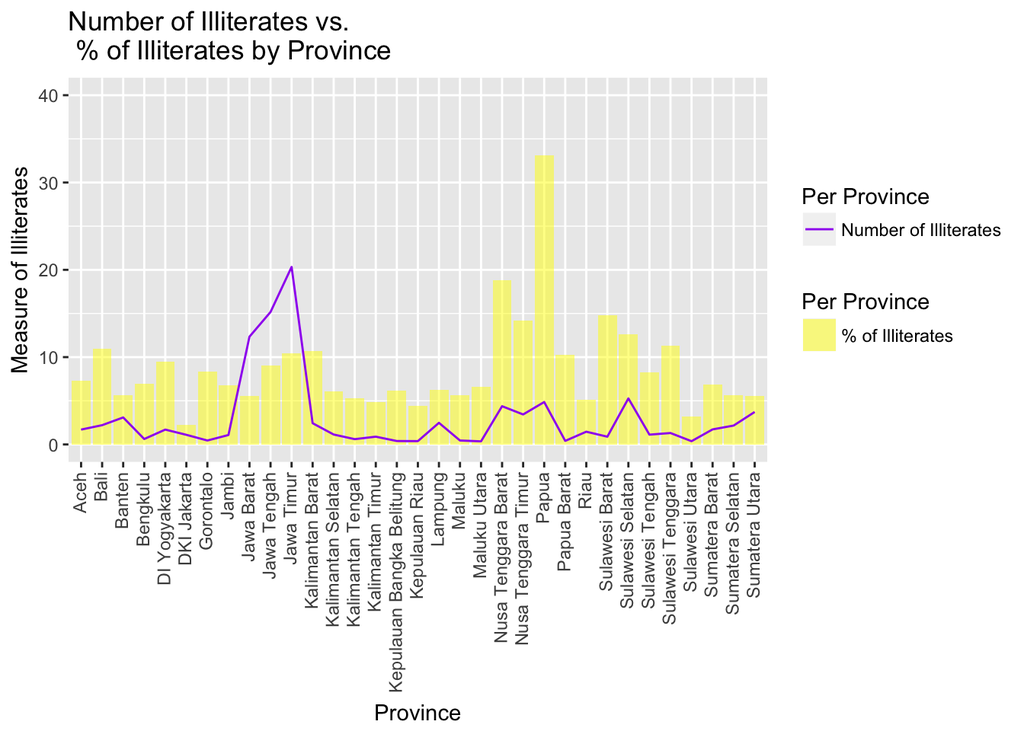

```r
plot_lit3 # illiterate percentage graph
```

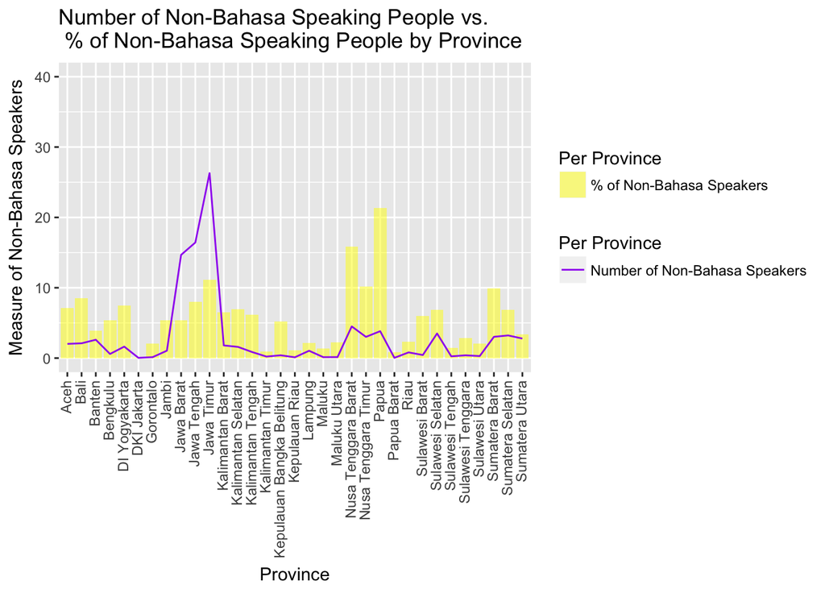

```r
plot_lit4 # non-Bahasa speakers percentage graph
```

# 4 Education Levels

In this next section, we will be focusing on various education level measures with respect to every province across the country in an attempt to visualize the demographic. The first step will be to load the dataset as shown below:

```r
education <- read.csv("education_demographic.csv")
```

After processing, here is a quick glance of what our education demographic data looks like:

```r
rbind(head(edu, 3), tail(edu,3))
```

```
##             province                level  total
## 1               Aceh             Tamat PT 253114
## 2               Bali             Tamat PT 259074
## 3             Banten             Tamat PT 554890
## 163   Sumatera Barat Tidak/Belum Tamat SD 362241
## 164 Sumatera Selatan Tidak/Belum Tamat SD 465493
## 165   Sumatera Utara Tidak/Belum Tamat SD 488827
```

The education levels (‘level’) are structured in the following manner:

- Tamat PT: Amount of people who graduated college
- Tamat SLTA: Amount of people who graduated high school
- Tamat SLTP: Amount of people who graduated junior high school
- Tamat SD: Amount of people who graduated elementary school
- Tidak/Belum Tamat SD: Amount of people who did or have NOT graduate elementary school

From here, we can then calculate student population percentages in each education level by province through the following calculations:

Total (of all Education Levels) = Tamat PT + Tamat SLTA + Tamat SLTP + Tamat SD + Tidak/Belum Tamat SD

Example: % Tamat PT = (Tamat PT) / (Total)

This is what our data looks like with percentage data instead of total number of students by province:

```r
rbind(head(data_c2, 3), tail(data_c2,3))
```

```
##             province   level percentage
## 1               Aceh college   8.700016
## 2               Bali college  10.178329
## 3             Banten college   7.864302
## 163   Sumatera Barat    none  11.357290
## 164 Sumatera Selatan    none   9.336328
## 165   Sumatera Utara    none   5.832976
```

Now, we are able to examine how each province fares in terms of their student population and education demographic as shown in the graphs below:

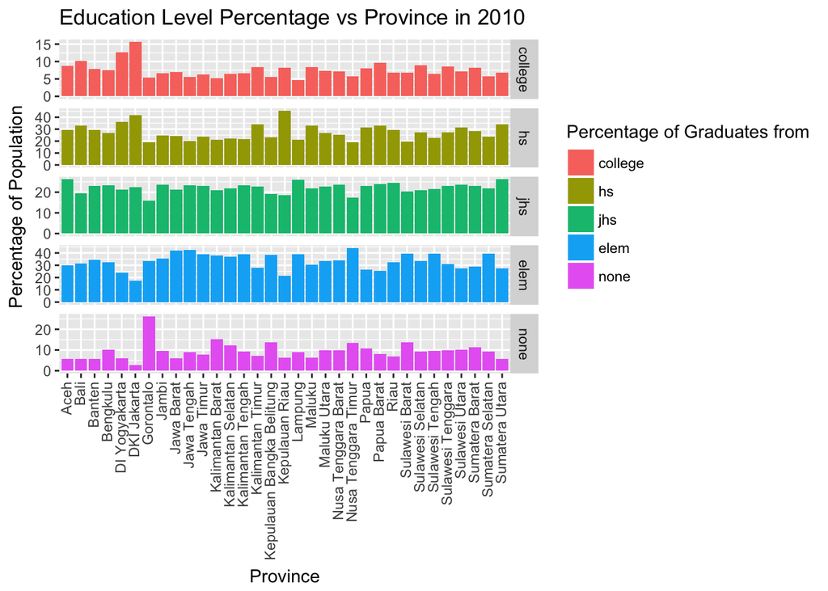

```r
plot_edu # education demographic graph
```

# 5 Unemployment and Labor Participation Rate

In the next dataset, we will inspect unemployment rate and labor participation rate among the 33 different provinces in Indonesia during the year of 2010.

```r
# importing unemployment rate and labor participation rate data
unemployment_2010 <- read.csv("tpt_provinsi_2010.csv")
```

Let us first start off with a few definitions to assist us in our understanding:

- Labor force: the amount of people who are ready to work and are also actively looking for employment
- Unemployment rate: the ratio of unemployed people to the labor force
- Labor force participation rate: the ratio of the labor force to the amount of people who are 15 years and above

The visualization below shows both the unemployment rate and labor participation rate in a single plot to make it easier for comparison.

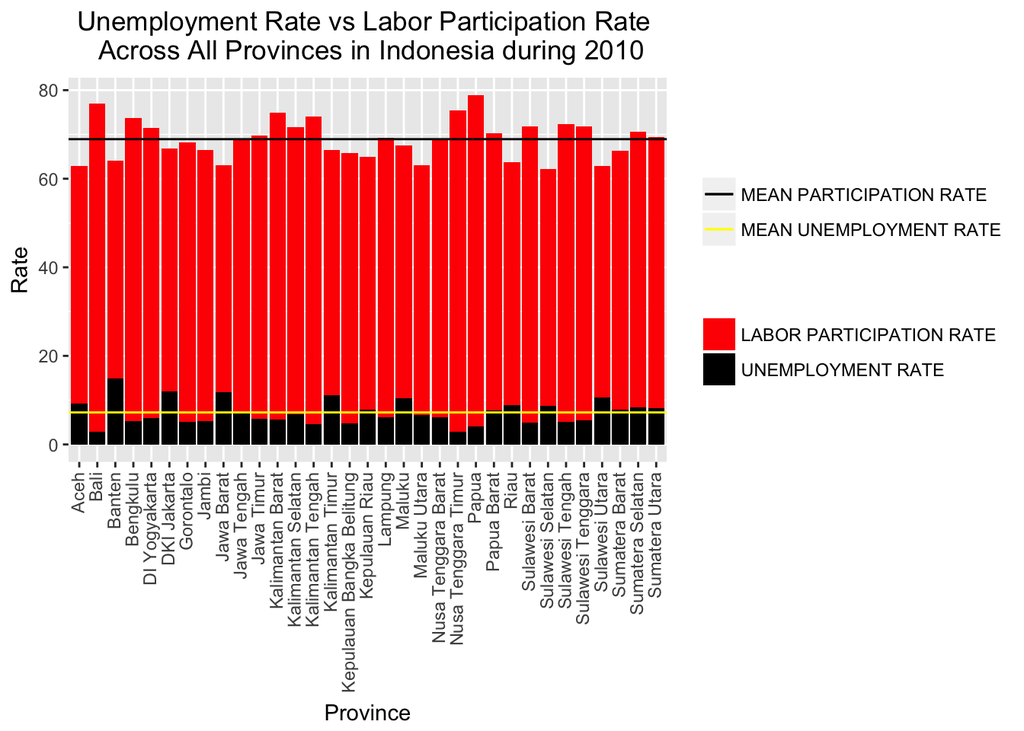

```r
plot_unempl1 # unemployment rate and labor participate rate graph
```

We can perform another visualization by working with geospatial plotting. For this purpose, we used an R package called “maps” which consists of many outlines of continents, countries, states, and counties.

The following represents an Indonesian map according to the R package we used:

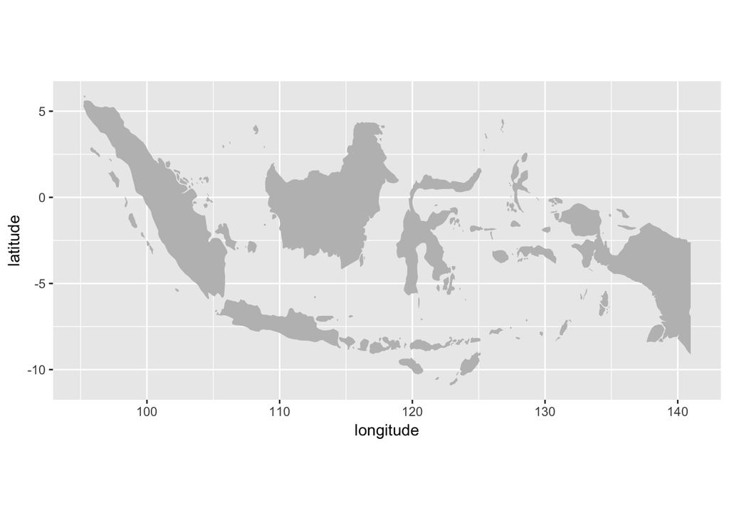

```r
id_map # map of Indonesia from the 'maps' package
```

The two plots below represent the following:

TOP: The labor participation rate with respect to provinces across Indonesia. In this case, purple represents areas with the lowest labor participation rates while yellow represents areas with the highest rates.

BOTTOM: The unemployment rate with respect to provinces across Indonesia. In this case, yellow represents areas with the lowest unemployment rates while purple represents areas with the highest rates.

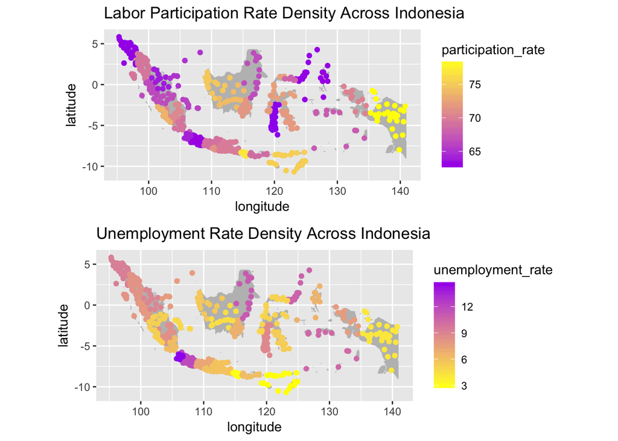

```r
grid.arrange(labor_map, unempl_map, nrow=2)
```

# 6 Closing Remarks

Connect with me through LinkedIn: https://www.linkedin.com/in/matthewjeremy/